# Estimation, Test of Hypothesis, and Confidence Intervals

## The Central Limit Theorem

- The **Central Limit Theorem** (CLT) is one of the most important theorems in statistics
- For our purposes, the CLT states that the distribution of averages of iid variables, properly normalized, becomes that of a standard normal as the sample size increases
- The CLT applies in an endless variety of settings
- Let \(X_1,\ldots,X_n\) be a collection of iid random variables with mean \(\mu\) and variance \(\sigma^2\)
- Let \(\bar X_n\) be their sample average
  - Then \(\frac{\bar X_n - \mu}{\sigma / \sqrt{n}}\) has a distribution like that of a standard normal for large \(n\).
- Remember the form \[\frac{\bar X_n - \mu}{\sigma / \sqrt{n}} = \frac{\mbox{Estimate} - \mbox{Mean of estimate}}{\mbox{Std. Err. of estimate}}. \]
- Usually, replacing the standard error by its estimated value doesn't change the CLT \[\frac{\bar X_n - \mu}{s / \sqrt{n}}\xrightarrow{p} N(0,1)\]

## Example: rolling of a die

Let \(X_i\) be the outcome for die \(i\)

\[ X_i = \begin{cases} 1 & 1/6 \\ 2 & 1/6 \\ 3 & 1/6 \\ 4 & 1/6 \\ 5 & 1/6 \\ 6 & 1/6 \end{cases} \]

- Then note that \[\mu = E[X_i] = 3.5, \quad Var(X_i) = 2.92 \]
- The Standard Error is SE \[\sqrt{2.92 / n} = 1.71 / \sqrt{n}\]
- Standardized mean \[ \frac{\bar X_n - 3.5}{1.71/\sqrt{n}} \]

## Example: rolling of a die, ctd

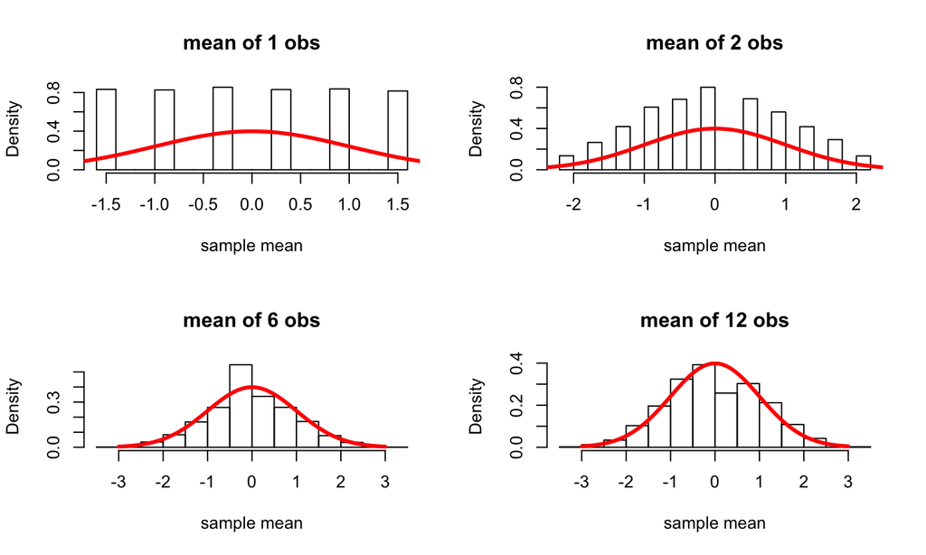

## Coin CLT

Let \(X_i\) be the \(0\) or \(1\) result of the \(i^{th}\) flip of a possibly unfair coin

- The sample proportion, say \(\hat p\), is the average of the coin flips
- \(E[X_i] = p\) and \(Var(X_i) = p(1-p)\)
- Standard error of the mean is \(\sqrt{p(1-p)/n}\)
- Then \[ \frac{\hat p - p}{\sqrt{p(1-p)/n}} \] will be approximately normally distributed

## CLT in practice

- In practice the CLT is mostly useful as an approximation \[ P\left( \frac{\bar X_n - \mu}{s / \sqrt{n}} \leq z \right) \approx \Phi(z). \]
- Recall \(1.96\) is a good approximation to the \(.975^{th}\) quantile of the standard normal
- Consider \[ \begin{eqnarray*} .95 & \approx & P\left( -1.96 \leq \frac{\bar X_n - \mu}{s / \sqrt{n}} \leq 1.96 \right)\\ \\ & = & P\left(\bar X_n +1.96 s/\sqrt{n} \geq \mu \geq \bar X_n - 1.96 s/\sqrt{n} \right),\\ \end{eqnarray*} \]

## Confidence intervals

- According to the CLT, the probability that the random interval \[\bar X_n \pm z_{1-\alpha/2}\sigma / \sqrt{n}\] contains \(\mu\) is approximately 100\((1-\alpha)\)%, where \(z_{1-\alpha/2}\) is the \(1-\alpha/2\) quantile of the standard normal distribution
  - \(\alpha = 0.10 \implies z_{.95} = 1.64\)
  - \(\alpha = 0.05 \implies z_{.975} = 1.96\)
  - \(\alpha = 0.01 \implies z_{.995} = 2.58\)
- This is called a \(100(1 - \alpha)\)% **confidence interval** for \(\mu\)
- We can replace the unknown \(\sigma\) with \(s\)
  - Intuition: \(s \xrightarrow{p} \sigma\) as \(n\to \infty\), "thus" \[ P\left(\frac{\bar X_n - \mu}{s / \sqrt{n}} \leq z \right) \approx P\left(\frac{\bar X_n - \mu}{\sigma / \sqrt{n}} \leq z \right) \]

## Notation and gergon

The normalized mean \[ \frac{\bar X - \mu}{s / \sqrt{n}} \] is often referred to as \(t\)-ratio or \(t\)-statistic when \(X_i\) is assumed to have a normal distribution

- In this case \(\frac{\bar X - \mu}{s / \sqrt{n}}\) is \(t\)-student distributed
- In general we refer to the normalized mean as \(z\)-statistic when \(\{X_i\}\), \(i=1, ldots,n\) are **not** assumed to be normal (as it will be the case in this course)
- However, statistical computer softwares keep referring to the ratio as \(t\)-statistic regardless of the assumpion made about the distribution of \(X_i\)

## Hypothesis testing

- Hypothesis testing is concerned with making decisions using data
- A null hypothesis is specified that represents the status quo, usually labeled \(H_0\)
- The null hypothesis is assumed true and statistical evidence is required to reject it in favor of a research or alternative hypothesis
- The alternative hypothesis is usually denoted by \(H_1\)

## Hypothesis testing, ctd

- The alternative hypotheses are typically of the form \(<\), \(>\) or \(\neq\)
- Note that there are four possible outcomes of our statistical decision process

| Truth | Decide | Result |
| --- | --- | --- |
| \(H_0\) | \(H_0\) | Correctly accept null |
| \(H_0\) | \(H_1\) | Type I error |
| \(H_1\) | \(H_1\) | Correctly reject null |
| \(H_1\) | \(H_0\) | Type II error |

## Discussion

- Consider a court of law; the null hypothesis is that the defendant is innocent
- We require evidence to reject the null hypothesis (convict)
  - If we require little evidence, then we would increase the percentage of innocent people convicted (**type I error**); however we would also increase the percentage of guilty people convicted (correctly rejecting the null)
  - If we require a lot of evidence, then we increase the the percentage of innocent people let free (correctly accepting the null) while we would also increase the percentage of guilty people let free (**type II error**)

## General rules

- The \(Z\) test for \(H_0:\mu = \mu_0\) versus
  - \(H_1: \mu < \mu_0\)
  - \(H_2: \mu \neq \mu_0\)
  - \(H_3: \mu > \mu_0\)
- Test statistic \(Z = \frac{\bar{X} - \mu_0}{s / \sqrt{n}}\) \[ s = \sqrt{\sum_{i=1}^n \frac{(X_i - \bar{X})^2}{n-1}} \]
- **Reject** the null hypothesis when
  - \(Z \leq -z_{1 - \alpha}\)
  - \(|Z| \geq z_{1 - \alpha / 2}\)
  - \(Z \geq z_{1 - \alpha}\)

## Statistical significance

Often we are interested in testing a "special" null hypothesis:

\[ H_0:\mu = 0$ \]

versus

\[ H_1: \mu \neq 0 \]

- **Reject** the null hypothesis when \[\left|\frac{\bar{X}}{s / \sqrt{n}}\right| \geq z_{1 - \alpha / 2}\]
- We we reject \(H_0\), we say that \(\mu\) is statistically different from zero, or, that \(\bar X\) **is statistically significant**.

## Notes

- We have fixed \(\alpha\) to be low, so if we reject \(H_0\) (either our model is wrong) or there is a low probability that we have made an error
- We have not fixed the probability of a type II error, \(\beta\); therefore we tend to say ``Fail to reject \(H_0\)'' rather than accepting \(H_0\)
- The region of \(Z\) values for which you reject \(H_0\) is called the rejection region

## Connections with confidence intervals

- Consider testing \(H_0: \mu = \mu_0\) versus \(H_1: \mu \neq \mu_0\)
- Take the set of all possible values for which you fail to reject \(H_0\), this set is a \((1-\alpha)100\%\) confidence interval for \(\mu\)
- The same works in reverse; if a \((1-\alpha)100\%\) interval contains \(\mu_0\), then we *fail to* reject \(H_0\)

## Example

Your campaign advisor told you that in a random sample of 100 likely voters, 56 intent to vote for you

- Can you relax? Do you have this race in the bag?
- Without access to a computer or calculator, how precise is this estimate?
- \(1/\sqrt{100}=.1\) so a back of the envelope calculation gives an approximate 95% interval of \[(0.46, 0.66)\]
- Not enough for you to relax, better go do more campaigning! (**Why?**)

## Example: SURVEY ON HOUSEHOLD INCOME AND WEALTH

The **Survey on Household Income and Wealth ([SHIW](https://www.bancaditalia.it/statistiche/indcamp/bilfait;internal&action=_setlanguage.action?LANGUAGE=en))** began in the 1960s with the aim of gathering data on the incomes and savings of Italian households. Over the years, the scope of the survey has grown and now includes wealth and other aspects of households' economic and financial behaviour such as, for example, which payment methods are used.

The sample used in the most recent surveys comprises about 8,000 households (24,000 individuals), distributed over about 300 Italian municipalities.

It is run by the Bank of Italy.

## Example: SURVEY ON HOUSEHOLD INCOME AND WEALTH, ctd.

The sample we consider is from the SHIW 2012 and it consists of all payroll workers. There are a total of 5555 observations.

## SHIW: Age of payroll workers

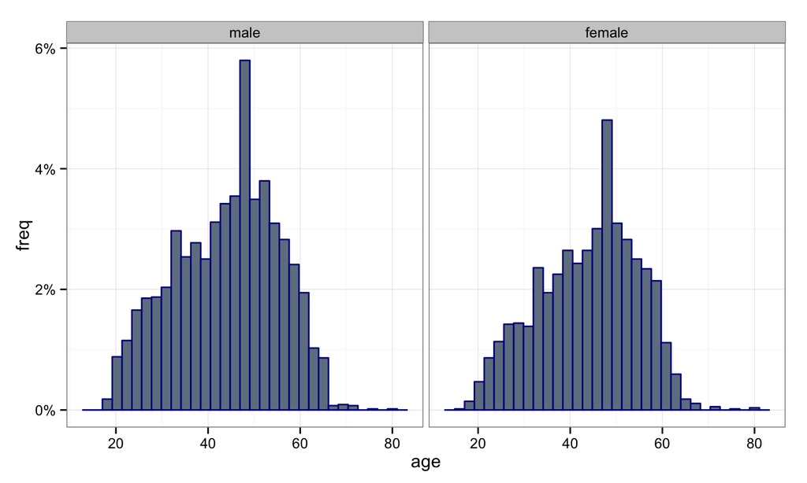

## SHIW: Education of payroll workers

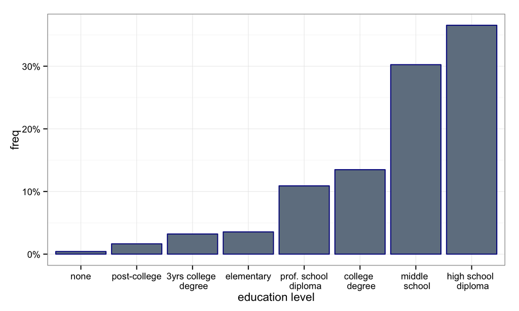

## SHIW: Education of all sample

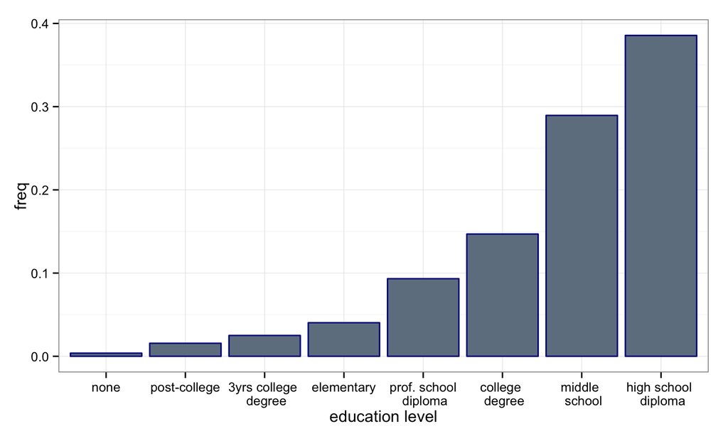

## SHIW: Labor income of payroll workers

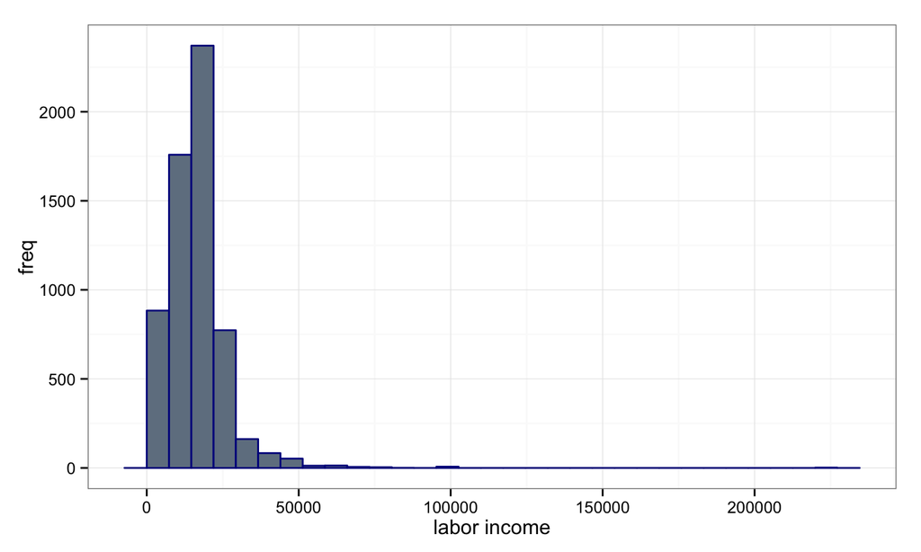

## SHIW: Labor income of payroll workers

```r
summary(payroll$yl)
```

```
##    Min. 1st Qu.  Median    Mean 3rd Qu.    Max.
##      90   11000   16000   16400   20000  220000
```

```r
sd(payroll$yl)
```

```
## [1] 9635
```

- The \(95\%\) confidence interval for the mean labor income:

```r
c(mean(payroll$yl) - 1.96*sd(payroll$yl)/sqrt(5550),
  mean(payroll$yl) + 1.96*sd(payroll$yl)/sqrt(5550))
```

```
## [1] 16181 16688
```

## SHIW: Labor income of payroll workers by gender

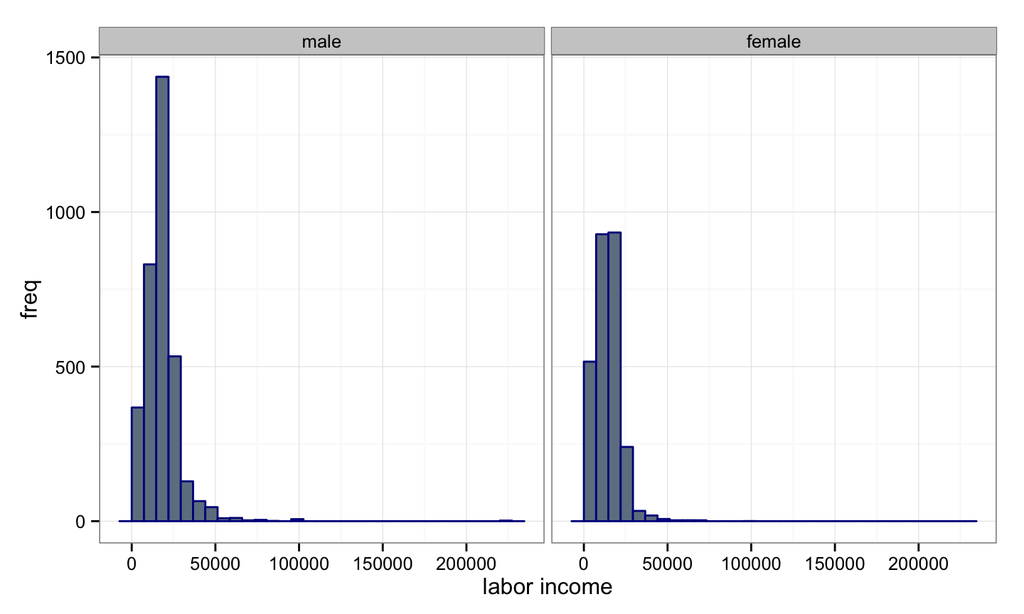

## SHIW: Labor income of payroll workers by gender

```
## Source: local data frame [2 x 4]
##
##      sex mean(yl) sd(yl)    n
## 1   male    18152  10664 3112
## 2 female    14247   7597 2443
```

Hypothesis:

- \(H_0: \mu_{female}-\mu_{male} = 0\)
- \(H_1: \mu_{female}-\mu_{male} \neq 0\)

## SHIW: Labor income of payroll workers by gender

```r
t.test(yl~sex, data=payroll, var.equal = FALSE, alternative = 'two.sided')
```

```
##
##  Welch Two Sample t-test
##
## data:  yl by sex
## t = 15.92, df = 5503, p-value < 2.2e-16
## alternative hypothesis: true difference in means is not equal to 0
## 95 percent confidence interval:
##  3424 4386
## sample estimates:
##   mean in group male mean in group female
##                18152                14247
```